# K Nearest Neighbors

Jameson Watts, Ph.D.

02/01/2020

## 0.1 Agenda

# 1 The KNN Algorithm

## 1.1 Algorithm

1. Load the data
2. Initialize K to your chosen number of neighbors
3. For each example in the data
4. Calculate the distance between the query example and the current example from the data.
5. Add the distance and the index of the example to an ordered collection
6. Sort the ordered collection of distances and indices from smallest to largest (in ascending order) by the distances
7. Pick the first K entries from the sorted collection
8. Get the labels of the selected K entries
9. If regression, return the mean of the K labels
10. If classification, return the mode of the K labels

## 1.2 Setup

```r
knitr::opts_chunk$set(echo = TRUE, message = FALSE, warning = FALSE)
library(tidyverse)
library(caret)
library(class)
library(fastDummies)
source('theme.R')
set.seed(5004)
wine = as.data.frame(read_rds("../resources/pinot.rds"))
```

# 2 Preprocessing

## 2.1 Caret preprocessing is so easy!

```r
wine %>%
  preProcess(method = c("BoxCox","center","scale")) %>%
  predict(wine) %>%
  head()
```

| province | price | points | year | taster_name | description |
| --- | --- | --- | --- | --- | --- |
| Oregon | 0.7146905 | -1.033841 | -0.0342533 | Paul Gregutt | Much like the regular bottling from 2012, this comes across as rather rough and tannic, with rustic, earthy, herbal characteristics. Nonetheless, if you think of it as a pleasantly unfussy country win… |
| Oregon | -1.4139991 | -1.033841 | 0.3331368 | Paul Gregutt | A sleek mix of tart berry, stem and herb, along with a hint of oak and chocolate, this is a fair value in a widely available, drink-now Oregon Pinot. The wine oak-aged for six months, whether in neutr… |
| California | 0.8225454 | -1.033841 | -0.4014609 | Virginie Boone | Oak and earth intermingle around robust aromas of wet forest floor in this vineyard-designated Pinot that hails from a high-elevation site. Small in production, it offers intense, full-bodied raspberr… |
| Oregon | 0.2408520 | -1.367722 | -0.7684859 | Paul Gregutt | As with many of the Erath 2010 vineyard designates, this is strongly herbal. The notes of leaf and herb create somewhat unripe flavor impressions, with a touch of bitterness on the finish. The fruit j… |
| Oregon | -1.2418658 | -1.367722 | -1.1353283 | Paul Gregutt | A stiff, tannic wine, this slowly opens and brings brambly berry flavors into play, along with notes of earthy herbs. There’s a touch of bitterness to the tannins. |
| Oregon | -1.0109945 | -1.367722 | 1.0684647 | Paul Gregutt | Some rosés are made simply by bleeding the juice from the fermenter, to concentrate the remaining wine. Whether or not that is the case here, the wine has the simple pleasant lightly candied strawberr… |

But wait… what is wrong here?

```r
wino <- wine %>%
  mutate(year_f = as.factor(year))

wino <- wino %>%
  preProcess(method = c("BoxCox","center","scale")) %>%
  predict(wino)

head(wino %>% select(starts_with("year")))
```

| year | year_f |
| --- | --- |
| -0.0342533 | 2012 |
| 0.3331368 | 2013 |
| -0.4014609 | 2011 |
| -0.7684859 | 2010 |
| -1.1353283 | 2009 |
| 1.0684647 | 2015 |

## 2.2 Engineering some features

```r
wino <- wino %>%
  mutate(taster_name = fct_lump(taster_name,5)) %>%
  dummy_cols(
    select_columns = c("year_f","taster_name"),
    remove_most_frequent_dummy = T,
    remove_selected_columns = T) %>%
  rename_all(funs(tolower(.))) %>%
  rename_all(funs(str_replace_all(., "-", "_"))) %>%
  rename_all(funs(str_replace_all(., " ", "_"))) %>%
  mutate(cherry = str_detect(description,"cherry")) %>%
  mutate(chocolate = str_detect(description,"chocolate")) %>%
  mutate(earth = str_detect(description,"earth")) %>%
  select(-description)

head(wino)
```

| province | price | points | year | year_f_1996 | year_f_1997 | year_f_1998 | year_f_1999 | year_f_2000 | year_f_2001 | year_f_2002 | year_f_2003 | year_f_2004 | year_f_2005 | year_f_2006 | year_f_2007 | year_f_2008 | year_f_2009 | year_f_2010 | year_f_2011 | year_f_2012 | year_f_2013 | year_f_2015 | taster_name_jim_gordon | taster_name_matt_kettmann | taster_name_roger_voss | taster_name_virginie_boone | taster_name_other | cherry | chocolate | … |
| --- | --- | --- | --- | --- | --- | --- | --- | --- | --- | --- | --- | --- | --- | --- | --- | --- | --- | --- | --- | --- | --- | --- | --- | --- | --- | --- | --- | --- | --- | --- |
| Oregon | 0.7146905 | -1.033841 | -0.0342533 | 0 | 0 | 0 | 0 | 0 | 0 | 0 | 0 | 0 | 0 | 0 | 0 | 0 | 0 | 0 | 0 | 1 | 0 | 0 | 0 | 0 | 0 | 0 | 0 | FALSE | FALSE | … |
| Oregon | -1.4139991 | -1.033841 | 0.3331368 | 0 | 0 | 0 | 0 | 0 | 0 | 0 | 0 | 0 | 0 | 0 | 0 | 0 | 0 | 0 | 0 | 0 | 1 | 0 | 0 | 0 | 0 | 0 | 0 | FALSE | TRUE | … |
| California | 0.8225454 | -1.033841 | -0.4014609 | 0 | 0 | 0 | 0 | 0 | 0 | 0 | 0 | 0 | 0 | 0 | 0 | 0 | 0 | 0 | 1 | 0 | 0 | 0 | 0 | 0 | 0 | 1 | 0 | FALSE | FALSE | … |
| Oregon | 0.2408520 | -1.367722 | -0.7684859 | 0 | 0 | 0 | 0 | 0 | 0 | 0 | 0 | 0 | 0 | 0 | 0 | 0 | 0 | 1 | 0 | 0 | 0 | 0 | 0 | 0 | 0 | 0 | 0 | FALSE | FALSE | … |
| Oregon | -1.2418658 | -1.367722 | -1.1353283 | 0 | 0 | 0 | 0 | 0 | 0 | 0 | 0 | 0 | 0 | 0 | 0 | 0 | 1 | 0 | 0 | 0 | 0 | 0 | 0 | 0 | 0 | 0 | 0 | FALSE | FALSE | … |
| Oregon | -1.0109945 | -1.367722 | 1.0684647 | 0 | 0 | 0 | 0 | 0 | 0 | 0 | 0 | 0 | 0 | 0 | 0 | 0 | 0 | 0 | 0 | 0 | 0 | 1 | 0 | 0 | 0 | 0 | 0 | FALSE | FALSE | … |

# 3 Basic Model

## 3.1 Simple model

```r
wine_index <- createDataPartition(wino$province, p = 0.75, list = FALSE)
train <- wino[ wine_index, ]
test <- wino[-wine_index, ]

fit <- knn(
  train = select(train,-province),
  test = select(test,-province),
  k=5,
  cl = train$province,
  prob = T)

confusionMatrix(fit,factor(test$province))
```

```
## Confusion Matrix and Statistics
##
##                    Reference
## Prediction          Burgundy California Casablanca_Valley Marlborough
##   Burgundy               292          0                 0           0
##   California               0        962                 0           0
##   Casablanca_Valley        0          0                10           5
##   Marlborough              0          1                13          29
##   New_York                 0          0                 3          12
##   Oregon                   6         26                 6          11
##                    Reference
## Prediction          New_York Oregon
##   Burgundy                 0      1
##   California               0      3
##   Casablanca_Valley        4      1
##   Marlborough             14      3
##   New_York                11      1
##   Oregon                   3    675
##
## Overall Statistics
##
##                Accuracy : 0.946
##                  95% CI : (0.9354, 0.9553)
##     No Information Rate : 0.4728
##     P-Value [Acc > NIR] : < 2.2e-16
##
##                   Kappa : 0.9165
##
##  Mcnemar's Test P-Value : NA
##
## Statistics by Class:
##
##                      Class: Burgundy Class: California
## Sensitivity                   0.9799            0.9727
## Specificity                   0.9994            0.9973
## Pos Pred Value                0.9966            0.9969
## Neg Pred Value                0.9967            0.9760
## Prevalence                    0.1424            0.4728
## Detection Rate                0.1396            0.4598
## Detection Prevalence          0.1401            0.4613
## Balanced Accuracy             0.9897            0.9850
##                      Class: Casablanca_Valley Class: Marlborough
## Sensitivity                           0.31250            0.50877
## Specificity                           0.99515            0.98477
## Pos Pred Value                        0.50000            0.48333
## Neg Pred Value                        0.98938            0.98622
## Prevalence                            0.01530            0.02725
## Detection Rate                        0.00478            0.01386
## Detection Prevalence                  0.00956            0.02868
## Balanced Accuracy                     0.65382            0.74677
##                      Class: New_York Class: Oregon
## Sensitivity                 0.343750        0.9868
## Specificity                 0.992233        0.9631
## Pos Pred Value              0.407407        0.9285
## Neg Pred Value              0.989831        0.9934
## Prevalence                  0.015296        0.3270
## Detection Rate              0.005258        0.3227
## Detection Prevalence        0.012906        0.3475
## Balanced Accuracy           0.667992        0.9750
```

## 3.2 Kappa statistic

Compares oberved accuracy against what would be expected by a random classifier.

- < 0.2 (not so good)
- 0.21 - 0.4 (ok)
- 0.41 - 0.6 (pretty good)
- 0.6 - 0.8 (great)
- > 0.8 (almost perfect)

…whoa! What’s going on here?

## 3.3 Fixing the leak

```r
wino <- select(wino, -starts_with("taster")) # get rid of the taster variables

wine_index <- createDataPartition(wino$province, p = 0.75, list = FALSE)
train <- wino[ wine_index, ]
test <- wino[-wine_index, ]

fit <- knn(
  train = select(train,-province),
  test = select(test,-province),
  k=5,
  cl = train$province,
  prob = T)

confusionMatrix(fit,factor(test$province))
```

```
## Confusion Matrix and Statistics
##
##                    Reference
## Prediction          Burgundy California Casablanca_Valley Marlborough
##   Burgundy               136         46                 2           6
##   California              79        744                14          14
##   Casablanca_Valley        0          4                 2           1
##   Marlborough              3          6                 1           8
##   New_York                 0          8                 2           2
##   Oregon                  80        181                11          26
##                    Reference
## Prediction          New_York Oregon
##   Burgundy                 2     62
##   California               7    251
##   Casablanca_Valley        0      2
##   Marlborough              7     15
##   New_York                 3      4
##   Oregon                  13    350
##
## Overall Statistics
##
##                Accuracy : 0.5942
##                  95% CI : (0.5728, 0.6153)
##     No Information Rate : 0.4728
##     P-Value [Acc > NIR] : < 2.2e-16
##
##                   Kappa : 0.3538
##
##  Mcnemar's Test P-Value : 1.869e-06
##
## Statistics by Class:
##
##                      Class: Burgundy Class: California
## Sensitivity                  0.45638            0.7523
## Specificity                  0.93423            0.6691
## Pos Pred Value               0.53543            0.6709
## Neg Pred Value               0.91186            0.7508
## Prevalence                   0.14245            0.4728
## Detection Rate               0.06501            0.3556
## Detection Prevalence         0.12141            0.5301
## Balanced Accuracy            0.69530            0.7107
##                      Class: Casablanca_Valley Class: Marlborough
## Sensitivity                          0.062500           0.140351
## Specificity                          0.996602           0.984275
## Pos Pred Value                       0.222222           0.200000
## Neg Pred Value                       0.985598           0.976121
## Prevalence                           0.015296           0.027247
## Detection Rate                       0.000956           0.003824
## Detection Prevalence                 0.004302           0.019120
## Balanced Accuracy                    0.529551           0.562313
##                      Class: New_York Class: Oregon
## Sensitivity                 0.093750        0.5117
## Specificity                 0.992233        0.7791
## Pos Pred Value              0.157895        0.5295
## Neg Pred Value              0.986011        0.7666
## Prevalence                  0.015296        0.3270
## Detection Rate              0.001434        0.1673
## Detection Prevalence        0.009082        0.3160
## Balanced Accuracy           0.542992        0.6454
```

# 4 Tuning, cross-validation and feature selection

## 4.1 Basic model with parameter tuning

```r
fit <- train(province ~ .,
             data = train,
             method = "knn",
             tuneLength = 15,
             trControl = trainControl(number = 1))
fit
```

```
## k-Nearest Neighbors
##
## 6288 samples
##   25 predictor
##    6 classes: 'Burgundy', 'California', 'Casablanca_Valley', 'Marlborough', 'New_York', 'Oregon'
##
## No pre-processing
## Resampling: Bootstrapped (1 reps)
## Summary of sample sizes: 6288
## Resampling results across tuning parameters:
##
##   k   Accuracy   Kappa
##    5  0.5812636  0.3518077
##    7  0.5877996  0.3589584
##    9  0.5891068  0.3543354
##   11  0.5934641  0.3582726
##   13  0.5960784  0.3608061
##   15  0.6000000  0.3637529
##   17  0.6030501  0.3644155
##   19  0.6052288  0.3648345
##   21  0.6074074  0.3670041
##   23  0.6200436  0.3851716
##   25  0.6187364  0.3828781
##   27  0.6191721  0.3842593
##   29  0.6126362  0.3708362
##   31  0.6143791  0.3728925
##   33  0.6152505  0.3733264
##
## Accuracy was used to select the optimal model using the largest value.
## The final value used for the model was k = 23.
```

## 4.2 Confusion Matrix

```r
confusionMatrix(predict(fit, test),factor(test$province))
```

```
## Confusion Matrix and Statistics
##
##                    Reference
## Prediction          Burgundy California Casablanca_Valley Marlborough
##   Burgundy               123         28                 1           4
##   California              93        836                16          24
##   Casablanca_Valley        0          0                 1           0
##   Marlborough              0          1                 1           0
##   New_York                 0          1                 1           2
##   Oregon                  82        123                12          27
##                    Reference
## Prediction          New_York Oregon
##   Burgundy                 1     48
##   California               7    305
##   Casablanca_Valley        0      1
##   Marlborough              2      2
##   New_York                 2      2
##   Oregon                  20    326
##
## Overall Statistics
##
##                Accuracy : 0.6157
##                  95% CI : (0.5944, 0.6366)
##     No Information Rate : 0.4728
##     P-Value [Acc > NIR] : < 2.2e-16
##
##                   Kappa : 0.3639
##
##  Mcnemar's Test P-Value : < 2.2e-16
##
## Statistics by Class:
##
##                      Class: Burgundy Class: California
## Sensitivity                  0.41275            0.8453
## Specificity                  0.95429            0.5966
## Pos Pred Value               0.60000            0.6526
## Neg Pred Value               0.90726            0.8113
## Prevalence                   0.14245            0.4728
## Detection Rate               0.05880            0.3996
## Detection Prevalence         0.09799            0.6123
## Balanced Accuracy            0.68352            0.7209
##                      Class: Casablanca_Valley Class: Marlborough
## Sensitivity                          0.031250           0.000000
## Specificity                          0.999515           0.997052
## Pos Pred Value                       0.500000           0.000000
## Neg Pred Value                       0.985167           0.972675
## Prevalence                           0.015296           0.027247
## Detection Rate                       0.000478           0.000000
## Detection Prevalence                 0.000956           0.002868
## Balanced Accuracy                    0.515382           0.498526
##                      Class: New_York Class: Oregon
## Sensitivity                 0.062500        0.4766
## Specificity                 0.997087        0.8125
## Pos Pred Value              0.250000        0.5525
## Neg Pred Value              0.985605        0.7617
## Prevalence                  0.015296        0.3270
## Detection Rate              0.000956        0.1558
## Detection Prevalence        0.003824        0.2820
## Balanced Accuracy           0.529794        0.6446
```

## 4.3 With parameter tuning, cross validation and Kappa

```r
fit <- train(province ~ .,
             data = train,
             method = "knn",
             tuneLength = 15,
             metric = "Kappa",
             trControl = trainControl(method = "repeatedcv"))

fit
```

```
## k-Nearest Neighbors
##
## 6288 samples
##   25 predictor
##    6 classes: 'Burgundy', 'California', 'Casablanca_Valley', 'Marlborough', 'New_York', 'Oregon'
##
## No pre-processing
## Resampling: Cross-Validated (10 fold, repeated 1 times)
## Summary of sample sizes: 5660, 5658, 5659, 5658, 5659, 5660, ...
## Resampling results across tuning parameters:
##
##   k   Accuracy   Kappa
##    5  0.5907957  0.3476117
##    7  0.6017746  0.3590702
##    9  0.6095650  0.3677498
##   11  0.6175149  0.3777243
##   13  0.6152902  0.3729715
##   15  0.6162453  0.3732996
##   17  0.6230854  0.3824817
##   19  0.6226036  0.3803676
##   21  0.6240438  0.3813502
##   23  0.6253182  0.3830440
##   25  0.6186392  0.3711074
##   27  0.6224540  0.3763550
##   29  0.6210204  0.3725357
##   31  0.6213388  0.3721555
##   33  0.6215014  0.3715902
##
## Kappa was used to select the optimal model using the largest value.
## The final value used for the model was k = 23.
```

## 4.4 Tuning plot

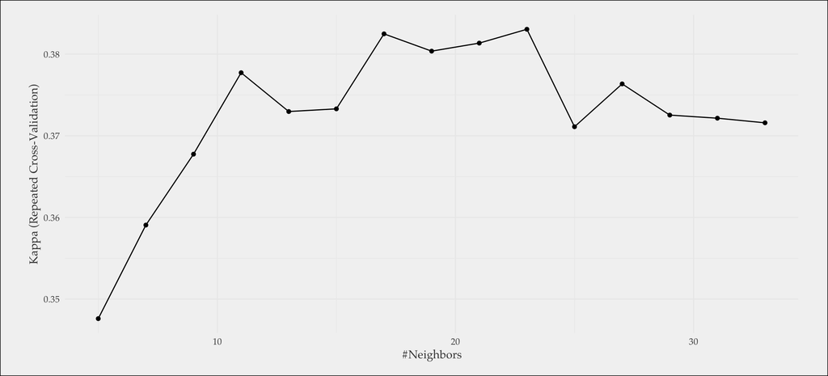

```r
ggplot(fit, metric="Kappa")
```

## 4.5 Group modeling problem I

- Practice running different versions of the model
- Create some new features and
- see if you can achieve a Kappa >= 0.5

# 5 Feature Selection and KNN for regression

## 5.1 Feature Selection

```r
x <- select(train,-province)
y <- train$province

# feature selection settings
rfeC <- rfeControl(functions = caretFuncs, method = "cv", number=2, verbose = F, returnResamp="final")
# cross validation settings
trC <- trainControl(method = "cv", number=2, verboseIter=F)
# feature sizes to try
sizes <- seq(2,ncol(x)-1,2)
# levels of K to try
knnG <- expand.grid(.k=seq(20, 30, 5))
knnR <- rfe(x, y, sizes = sizes, tuneGrid = knnG, rfeControl = rfeC, method="knn", trControl=trC)
knnR
```

```
##
## Recursive feature selection
##
## Outer resampling method: Cross-Validated (2 fold)
##
## Resampling performance over subset size:
##
##  Variables Accuracy  Kappa AccuracySD  KappaSD Selected
##          2   0.5304 0.2044  0.0026852 0.004390
##          4   0.5905 0.3104  0.0008589 0.011240
##          6   0.5983 0.3216  0.0079159 0.018291
##          8   0.5976 0.3194  0.0092651 0.023270
##         10   0.5959 0.3160  0.0067903 0.019970
##         12   0.5970 0.3193  0.0083652 0.018925
##         14   0.5934 0.3132  0.0013914 0.013151
##         16   0.5905 0.3083  0.0067879 0.020051
##         18   0.5916 0.3077  0.0088126 0.019255
##         20   0.5945 0.3131  0.0061150 0.020122
##         22   0.5907 0.3096  0.0052136 0.019578
##         24   0.6043 0.3370  0.0070190 0.016686
##         25   0.6120 0.3538  0.0016247 0.004952        *
##
## The top 5 variables (out of 25):
##    cherry, chocolate, earth, points, price
```

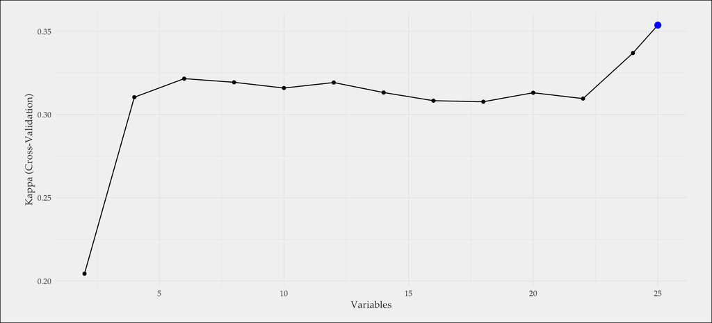

```r
ggplot(knnR, metric = "Kappa")
```

## 5.2 KNN for regression

```r
fit <- train(price ~ .,
             data = train,
             method = "knn",
             tuneLength = 15,
             trControl = trainControl(number = 1))
fit
```

```
## k-Nearest Neighbors
##
## 6288 samples
##   25 predictor
##
## No pre-processing
## Resampling: Bootstrapped (1 reps)
## Summary of sample sizes: 6288
## Resampling results across tuning parameters:
##
##   k   RMSE       Rsquared   MAE
##    5  0.7619611  0.4637159  0.5773573
##    7  0.7528114  0.4746120  0.5706789
##    9  0.7551012  0.4699122  0.5711210
##   11  0.7547466  0.4703366  0.5693409
##   13  0.7575594  0.4669080  0.5710287
##   15  0.7565092  0.4682353  0.5696444
##   17  0.7602878  0.4635265  0.5714079
##   19  0.7557253  0.4701979  0.5697230
##   21  0.7501339  0.4803900  0.5665858
##   23  0.7514263  0.4792217  0.5673022
##   25  0.7532121  0.4774669  0.5679150
##   27  0.7541282  0.4774253  0.5688160
##   29  0.7568733  0.4743166  0.5695289
##   31  0.7549337  0.4777766  0.5685316
##   33  0.7590372  0.4734046  0.5700359
##
## RMSE was used to select the optimal model using the smallest value.
## The final value used for the model was k = 21.
```